# Can Fun Lead to Winning in the NFL

Josh Feenberg

2023-12-27

When watching NFL games, I find that when teams throw deep passes, it tends to be more enjoyable to watch. I have also come to notice that the teams that air it out more tend to win the game. In this project, I will see if this is true.

I will use two terms, EPA and air yards. For more information on those, read here: https://www.the33rdteam.com/epa-explained/#:~:text=Expected%20Points%20Added%2C%20commonly%20referred,drive%20would%20be%20about%202.5.

https://www.ftnfantasy.com/air-yards?fppg=PPR&years=2023

ALL Data used in this project is from https://www.nflfastr.com/articles/nflfastR.html

```r
#add libraries used in the project
library(nflfastR)
library(tidyverse)
library(dplyr)
library(viridis)
#read in data
all_data = read_csv("https://github.com/ryurko/nflscrapR-data/blob/master/play_by_play_data/regular_season/reg_pbp_2019.csv?raw=true")
```

In the initial data filtering stage, I have selectively chosen plays for analysis, focusing on situations where the team possesses the ball and is not strategically positioned for a pass. Specifically, I have isolated pass plays that occur during the first half of the game when the team faces a 1st and 10 scenario on their own side of the field. This refined dataset enables a targeted examination of plays in situations where external factors do not necessitate a further advancement through passing, thereby providing a more focused and meaningful analysis.

```r
fdand10_ownside_fhalf <- all_data %>%
  # get pass plays in the first half where the home team has the ball on first and ten on their own side of the field as those are neutral pass/run situations
  filter(game_half == "Half1" & down == 1 & ydstogo == 10 & defteam != side_of_field & home_team == posteam & play_type == 'pass') %>%
  mutate(score_differential)
```

Here, I conduct a linear regression to explore the correlation between air yards and EPA.

```r
lm_model_epa = lm(data = fdand10_ownside_fhalf, epa ~ air_yards)
summary(lm_model_epa)
```

```
##
## Call:
## lm(formula = epa ~ air_yards, data = fdand10_ownside_fhalf)
##
## Residuals:
##     Min      1Q  Median      3Q     Max
## -6.7694 -0.7118  0.0196  0.6798  6.2883
##
## Coefficients:
##             Estimate Std. Error t value Pr(>|t|)
## (Intercept) 0.056651   0.050314   1.126     0.26
## air_yards   0.020609   0.003502   5.884 5.55e-09 ***
## ---
## Signif. codes:  0 '***' 0.001 '**' 0.01 '*' 0.05 '.' 0.1 ' ' 1
##
## Residual standard error: 1.245 on 943 degrees of freedom
##   (53 observations deleted due to missingness)
## Multiple R-squared:  0.03542,    Adjusted R-squared:  0.03439
## F-statistic: 34.62 on 1 and 943 DF,  p-value: 5.555e-09
```

Next, I will create a plot to visually depict the relationship between the EPA and Air Yards.

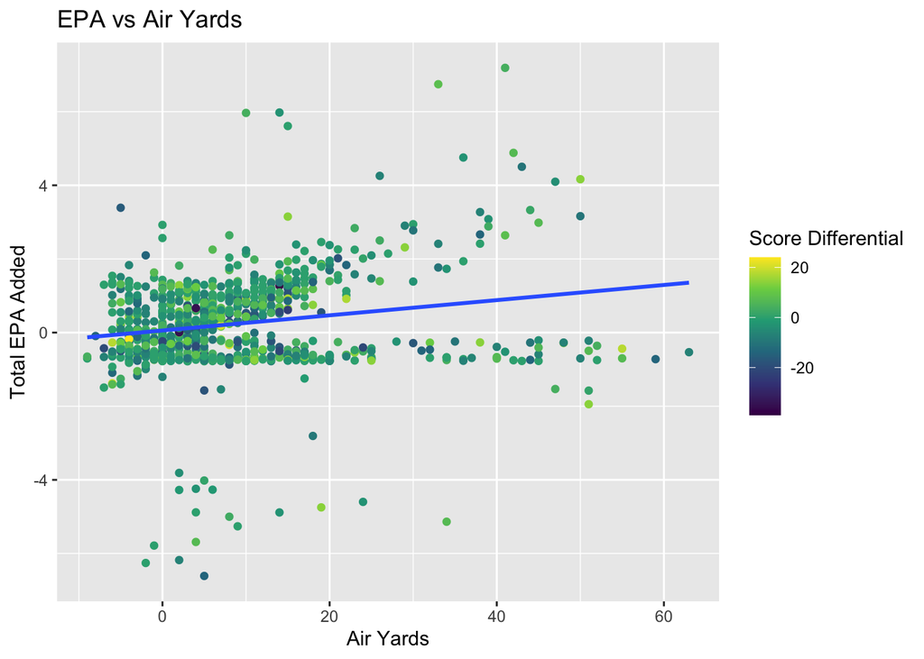

```r
ggplot(data = fdand10_ownside_fhalf, aes(x = air_yards, y = epa, color = score_differential)) +
  geom_point() +
  geom_smooth(method = "lm", se = FALSE) +
  scale_color_viridis_c(name = "Score Differential" ) +
  labs(title = "EPA vs Air Yards",
       x = "Air Yards",
       y = "Total EPA Added")
```